# Geodatenanalyse 2

## Termin: Big Data 2 - Modul 1

## Frequenzanalyse von Zeitreihen: Motivation und Grundlage

Ca. 20-30 Minuten

## Inhalt

- Beispiel: Eine Meeresspiegel Zeitreihe
- Fourier Analyse
- Beispiel: Zusammengesetzte Komponenten
- Fast Fourier Transform (FFT)
- Anwendung auf die Meeresspiegel Zeitreihe

```python
import numpy as np
import matplotlib.pyplot as plt
import pandas as pd
```

**Hinweis**: In dieser Vorlesung wird auf das wunderbare Online-Material von [Jack Schaedler zur digitalen Signalverarbeitung](https://jackschaedler.github.io/circles-sines-signals/index.html) hingewiesen.

## Beispiel: Eine Meeresspiegel Zeitreihe

Daten sind von Palau, gemessen vom [Sea Level Center der University of Hawaii](https://uhslc.soest.hawaii.edu/stations/?stn=007#levels)

```python
sea_level = pd.read_csv('data/Palau_sea-level.csv')
sea_level['Datetime[GMT]'] = pd.to_datetime(sea_level['Datetime[GMT]'], dayfirst=True)
sea_level.set_index('Datetime[GMT]', inplace=True)

sea_level = sea_level[sea_level.index > '2018-01-01']
sea_level
```

| Datetime[GMT] | Sea level [mm] |
| --- | --- |
| 2018-01-01 01:00:00 | 1506 |
| 2018-01-01 02:00:00 | 1283 |
| 2018-01-01 03:00:00 | 1166 |
| 2018-01-01 04:00:00 | 1207 |
| 2018-01-01 05:00:00 | 1425 |
| ... | ... |
| 2018-12-31 19:00:00 | 1566 |
| 2018-12-31 20:00:00 | 1496 |
| 2018-12-31 21:00:00 | 1372 |
| 2018-12-31 22:00:00 | 1218 |
| 2018-12-31 23:00:00 | 1062 |

8759 rows × 1 columns

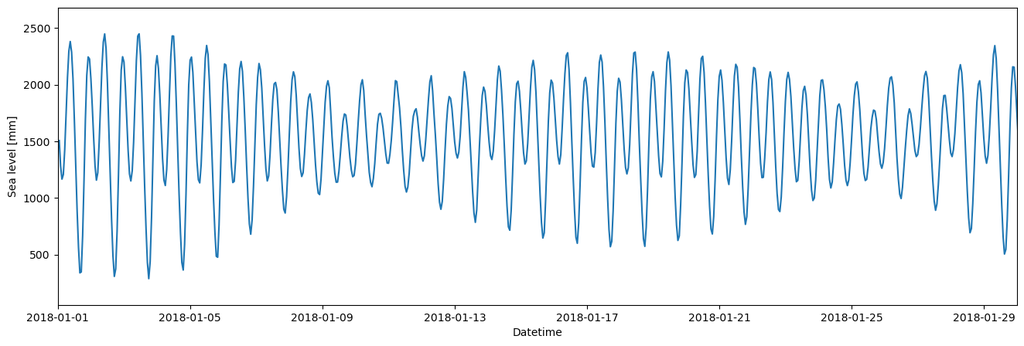

```python
fig, ax = plt.subplots(figsize=(16, 5))

ax.plot(sea_level.index, sea_level['Sea level [mm]'])
ax.set_xlim(np.datetime64('2018-01-01'), np.datetime64('2018-01-30'))
ax.set_xlabel('Datetime')
ax.set_ylabel('Sea level [mm]')

plt.show()
```

### Beobachtungen

- Viele Zeitreihen enthalten zyklische Schwingungen mit unterschiedlichen Perioden
- Wir können Zeitreihen in ihre Komponenten zerlegen
- Die bekannteste Methode ist die schnelle Fourier-Transformation

## Fourier Analyse

- In der Mathematik ist eine Fourier-Reihe eine periodische Funktion, die sich aus harmonisch zusammenhängenden Sinuskurven zusammensetzt, die durch eine gewichtete Summation kombiniert werden.
- Mit geeigneten Gewichten kann ein Zyklus (oder eine Periode) der Summation dazu gebracht werden, eine beliebige Funktion in diesem Intervall zu approximieren (oder die gesamte Funktion, wenn sie ebenfalls periodisch ist).
- Als solche ist die Summation eine Synthese einer anderen Funktion.

### Diskrete Fourier-Transformation (DFT)

Kann man auf Zeitreihen anwenden, welche in regelmäßigen Abständen gemessen wurden:

$DFT[k] = \sum_{n = 0}^{N - 1} x[n] \cdot e^{- \phi i} = x[n] \cdot (cos(\phi) - sin(\phi)i)$

wo

$\phi = k \frac{n}{N} 2 \pi$

*Frage*: Was ist hier $i$?

### Umweg: Komplexe Zahlen

Die komplexen Zahlen erweitern den Zahlenbereich auf dass die Gleichung $x^2 = -1$ lösbar wird:

Quelle: [Wikipedia](https://de.wikipedia.org/wiki/Komplexe_Zahl)

[figure not shown]

Komplexe Zahlen werden in *NumPy* unterstützt:

```python
compl_number = 3 + 2j
compl_number
```

```
(3+2j)
```

```python
np.real(compl_number)
```

```
3.0
```

```python
np.imag(compl_number)
```

```
2.0
```

```python
np.abs(compl_number)
```

```
3.605551275463989
```

```python
print('Angle in radians: {:.2f}'.format(np.angle(compl_number)))
print('Angle in degrees: {:.2f}°'.format(np.degrees(np.angle(compl_number))))
```

```
Angle in radians: 0.59
Angle in degrees: 33.69°
```

### Verbindung zur Sinus- und Cosinus-Funktion

Siehe Beispiel von [Jack Schaedler](https://jackschaedler.github.io/circles-sines-signals/sincos.html)

## Beispiel: Zusammengesetzte Komponenten

Als Beispiel "basteln" wir ein paar Zeitreihen-Komponenten:

```python
# a linear time vector
time = np.linspace(0, 10, 10*96, endpoint=True)
time
```

[output not shown]

[output cut: 137 more lines]

[output not shown]

```python
# component 1
freq1 = 1
amp1 = 1
comp1 = amp1 * np.cos(time*2*np.pi*freq1)

# component 2
freq2 = 0.5
amp2 = 3
comp2 = amp2 * np.cos(time*2*np.pi*freq2)

# component 3
freq3 = 2
amp3 = 2
comp3 = amp3 * np.cos(time*2*np.pi*freq3)

# all combined ...
comp_sum = comp1 + comp2 + comp3
```

Wie sieht das aus?

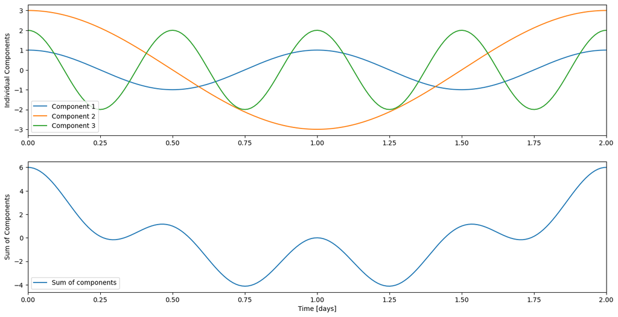

```python
fig, ax = plt.subplots(2, 1, figsize=(16, 8))

ax[0].plot(time, comp1, label='Component 1')
ax[0].plot(time, comp2, label='Component 2')
ax[0].plot(time, comp3, label='Component 3')
ax[0].set_xlim(0, 2)
ax[0].set_ylabel('Individual Components')
ax[0].legend()

ax[1].plot(time, comp_sum, label='Sum of components')
ax[1].set_xlim(0, 2)
ax[1].set_xlabel('Time [days]')
ax[1].set_ylabel('Sum of Components')
ax[1].legend()

plt.show()
```

**HINWEIS**: Mit der DFT kann man diesen Summationsprozess umkehren, d.h. eine Zeitreihe in Komponenten bestimmter Frequenzen zerlegen. Allerdings muss man hier einige Dinge beachten!

## Fast Fourier Transform (FFT)

- Eine schnelle Fourier-Transformation (FFT) ist ein Algorithmus, der die diskrete Fourier-Transformation (DFT) einer Sequenz oder deren Inverse (IDFT) berechnet
- Die Fourier-Analyse wandelt ein Signal von seiner ursprünglichen Domäne (oft Zeit oder Raum) in eine Darstellung im Frequenzbereich um, und umgekehrt für die inverse Transformation
- Die DFT erhält man, indem man eine Folge von Werten in Komponenten unterschiedlicher Frequenzen zerlegt

### *NumPy*'s *fft()* Funktion

Nun wird über *NumPy* die *FFT* funktion angewendet.

**Achtung**: Das Ergebnis ist komplex, hat zwei Seiten (!) und muss deshalb angepasst werden

```python
# Anzahl der Datenwerte
N = len(comp_sum)

# Anzahl der Werte pro Frequenzeinheit
T = 96
```

```python
# calculate the FFT
data_fft = np.fft.fft(comp_sum)

# only use half the data
data_fft = data_fft[0:int(N/2)]
data_fft
```

```
array([ 6.00000000e+00+0.00000000e+00j,  6.13976690e+00+2.00924119e-02j,
        6.63155911e+00+4.34040726e-02j,  7.82612588e+00+7.68352797e-02j,
        1.15744336e+01+1.51517636e-01j,  1.44395808e+03+2.36288175e+01j,
       -3.10614353e+00-6.09968246e-02j,  1.09668408e+00+2.51266270e-02j,
        3.21640112e+00+8.42244274e-02j,  6.37634002e+00+1.87853036e-01j,
        4.81568178e+02+1.57649098e+01j, -2.73587407e+00-9.85269577e-02j,
        2.00972898e-01+7.89624667e-03j,  1.47733918e+00+6.28874986e-02j,
        2.42458442e+00+1.11159861e-01j,  3.37490669e+00+1.65798534e-01j,
        4.55807659e+00+2.38878672e-01j,  6.33971707e+00+3.53057793e-01j,
        9.71201605e+00+5.72747558e-01j,  1.94667061e+01+1.21195050e+00j,
        9.57226446e+02+6.27399360e+01j, -2.03696744e+01-1.40205956e+00j,
       -1.00295763e+01-7.23327823e-01j, -6.61275114e+00-4.98666115e-01j,
       -4.90344337e+00-3.85909362e-01j, -3.87511161e+00-3.17741051e-01j,
       -3.18746175e+00-2.71860905e-01j, -2.69493049e+00-2.38738365e-01j,
       -2.32473436e+00-2.13613080e-01j, -2.03638806e+00-1.93840152e-01j,
       -1.80555045e+00-1.77831197e-01j, -1.61669125e+00-1.64573863e-01j,
       -1.45942605e+00-1.53391859e-01j, -1.32654254e+00-1.43815821e-01j,
       -1.21287193e+00-1.35509537e-01j, -1.11461099e+00-1.28225671e-01j,
       -1.02889784e+00-1.21778084e-01j, -9.53536840e-01-1.16023915e-01j,
       -8.86814993e-01-1.10851617e-01j, -8.27375914e-01-1.06172772e-01j,
       -7.74131491e-01-1.01916344e-01j, -7.26198606e-01-9.80245803e-02j,
       -6.82852997e-01-9.44500141e-02j, -6.43495080e-01-9.11532545e-02j,
       -6.07624239e-01-8.81013218e-02j, -5.74819246e-01-8.52663805e-02j,
       -5.44723148e-01-8.26247633e-02j, -5.17031495e-01-8.01562103e-02j,
       -4.91483061e-01-7.78432696e-02j, -4.67852464e-01-7.56708210e-02j,
       -4.45944254e-01-7.36256942e-02j, -4.25588129e-01-7.16963603e-02j,
       -4.06635044e-01-6.98726798e-02j, -3.88954017e-01-6.81456969e-02j,
       -3.72429491e-01-6.65074686e-02j, -3.56959152e-01-6.49509239e-02j,
       -3.42452099e-01-6.34697449e-02j, -3.28827310e-01-6.20582681e-02j,
       -3.16012353e-01-6.07113998e-02j, -3.03942287e-01-5.94245456e-02j,
       -2.92558730e-01-5.81935496e-02j, -2.81809060e-01-5.70146418e-02j,
       -2.71645735e-01-5.58843944e-02j, -2.62025696e-01-5.47996827e-02j,
       -2.52909866e-01-5.37576516e-02j, -2.44262701e-01-5.27556870e-02j,
       -2.36051807e-01-5.17913902e-02j, -2.28247606e-01-5.08625559e-02j,
       -2.20823039e-01-4.99671524e-02j, -2.13753310e-01-4.91033050e-02j,
       -2.07015655e-01-4.82692807e-02j, -2.00589147e-01-4.74634745e-02j,
       -1.94454512e-01-4.66843980e-02j, -1.88593978e-01-4.59306685e-02j,
       -1.82991127e-01-4.52009998e-02j, -1.77630778e-01-4.44941937e-02j,
       -1.72498872e-01-4.38091324e-02j, -1.67582369e-01-4.31447719e-02j,
       -1.62869166e-01-4.25001356e-02j, -1.58348011e-01-4.18743091e-02j,
```

[output cut: 185 more lines]

```
       -1.01750853e-04-1.03309375e-03j, -9.50400796e-05-9.98443724e-04j,
       -8.85622049e-05-9.63815517e-04j, -8.23166627e-05-9.29208359e-04j,
       -7.63029096e-05-8.94621484e-04j, -7.05204208e-05-8.60054125e-04j,
       -6.49686929e-05-8.25505516e-04j, -5.96472437e-05-7.90974896e-04j,
       -5.45556094e-05-7.56461502e-04j, -4.96933493e-05-7.21964576e-04j,
       -4.50600400e-05-6.87483359e-04j, -4.06552804e-05-6.53017094e-04j,
       -3.64786884e-05-6.18565025e-04j, -3.25299022e-05-5.84126397e-04j,
       -2.88085803e-05-5.49700459e-04j, -2.53144004e-05-5.15286457e-04j,
       -2.20470602e-05-4.80883640e-04j, -1.90062776e-05-4.46491259e-04j,
       -1.61917895e-05-4.12108564e-04j, -1.36033532e-05-3.77734807e-04j,
       -1.12407450e-05-3.43369240e-04j, -9.10376095e-06-3.09011116e-04j,
       -7.19221728e-06-2.74659690e-04j, -5.50594782e-06-2.40314215e-04j,
       -4.04480898e-06-2.05973947e-04j, -2.80867342e-06-1.71638141e-04j,
       -1.79743488e-06-1.37306052e-04j, -1.01100616e-06-1.02976938e-04j,
       -4.49319972e-07-6.86500530e-05j, -1.12327557e-07-3.43246548e-05j])
```

### *NumPy*'s *fftfreq()* Funktion

Diese Funktion berechnet aus der diskreten Abtastung in der Zeitdomäne die äquivalente Abtastung in der Frequenzdomäne.

**Achtung**: Die Einheit der Frequenzdomäne ist hier 1/Zeit, z.B. Hertz (1/Sekunde) oder Zyklen pro Tag (1/Tag) (Engl. "cycles per day" cpd)

```python
# calculate the frequency spacing
freq = np.fft.fftfreq(N, d=1/T)

# only use half the data
freq = freq[0:int(N/2)]
freq
```

```
array([ 0. ,  0.1,  0.2,  0.3,  0.4,  0.5,  0.6,  0.7,  0.8,  0.9,  1. ,
        1.1,  1.2,  1.3,  1.4,  1.5,  1.6,  1.7,  1.8,  1.9,  2. ,  2.1,
        2.2,  2.3,  2.4,  2.5,  2.6,  2.7,  2.8,  2.9,  3. ,  3.1,  3.2,
        3.3,  3.4,  3.5,  3.6,  3.7,  3.8,  3.9,  4. ,  4.1,  4.2,  4.3,
        4.4,  4.5,  4.6,  4.7,  4.8,  4.9,  5. ,  5.1,  5.2,  5.3,  5.4,
        5.5,  5.6,  5.7,  5.8,  5.9,  6. ,  6.1,  6.2,  6.3,  6.4,  6.5,
        6.6,  6.7,  6.8,  6.9,  7. ,  7.1,  7.2,  7.3,  7.4,  7.5,  7.6,
        7.7,  7.8,  7.9,  8. ,  8.1,  8.2,  8.3,  8.4,  8.5,  8.6,  8.7,
        8.8,  8.9,  9. ,  9.1,  9.2,  9.3,  9.4,  9.5,  9.6,  9.7,  9.8,
        9.9, 10. , 10.1, 10.2, 10.3, 10.4, 10.5, 10.6, 10.7, 10.8, 10.9,
       11. , 11.1, 11.2, 11.3, 11.4, 11.5, 11.6, 11.7, 11.8, 11.9, 12. ,
       12.1, 12.2, 12.3, 12.4, 12.5, 12.6, 12.7, 12.8, 12.9, 13. , 13.1,
       13.2, 13.3, 13.4, 13.5, 13.6, 13.7, 13.8, 13.9, 14. , 14.1, 14.2,
       14.3, 14.4, 14.5, 14.6, 14.7, 14.8, 14.9, 15. , 15.1, 15.2, 15.3,
       15.4, 15.5, 15.6, 15.7, 15.8, 15.9, 16. , 16.1, 16.2, 16.3, 16.4,
       16.5, 16.6, 16.7, 16.8, 16.9, 17. , 17.1, 17.2, 17.3, 17.4, 17.5,
       17.6, 17.7, 17.8, 17.9, 18. , 18.1, 18.2, 18.3, 18.4, 18.5, 18.6,
       18.7, 18.8, 18.9, 19. , 19.1, 19.2, 19.3, 19.4, 19.5, 19.6, 19.7,
       19.8, 19.9, 20. , 20.1, 20.2, 20.3, 20.4, 20.5, 20.6, 20.7, 20.8,
       20.9, 21. , 21.1, 21.2, 21.3, 21.4, 21.5, 21.6, 21.7, 21.8, 21.9,
       22. , 22.1, 22.2, 22.3, 22.4, 22.5, 22.6, 22.7, 22.8, 22.9, 23. ,
       23.1, 23.2, 23.3, 23.4, 23.5, 23.6, 23.7, 23.8, 23.9, 24. , 24.1,
       24.2, 24.3, 24.4, 24.5, 24.6, 24.7, 24.8, 24.9, 25. , 25.1, 25.2,
       25.3, 25.4, 25.5, 25.6, 25.7, 25.8, 25.9, 26. , 26.1, 26.2, 26.3,
       26.4, 26.5, 26.6, 26.7, 26.8, 26.9, 27. , 27.1, 27.2, 27.3, 27.4,
       27.5, 27.6, 27.7, 27.8, 27.9, 28. , 28.1, 28.2, 28.3, 28.4, 28.5,
       28.6, 28.7, 28.8, 28.9, 29. , 29.1, 29.2, 29.3, 29.4, 29.5, 29.6,
       29.7, 29.8, 29.9, 30. , 30.1, 30.2, 30.3, 30.4, 30.5, 30.6, 30.7,
       30.8, 30.9, 31. , 31.1, 31.2, 31.3, 31.4, 31.5, 31.6, 31.7, 31.8,
       31.9, 32. , 32.1, 32.2, 32.3, 32.4, 32.5, 32.6, 32.7, 32.8, 32.9,
       33. , 33.1, 33.2, 33.3, 33.4, 33.5, 33.6, 33.7, 33.8, 33.9, 34. ,
       34.1, 34.2, 34.3, 34.4, 34.5, 34.6, 34.7, 34.8, 34.9, 35. , 35.1,
       35.2, 35.3, 35.4, 35.5, 35.6, 35.7, 35.8, 35.9, 36. , 36.1, 36.2,
       36.3, 36.4, 36.5, 36.6, 36.7, 36.8, 36.9, 37. , 37.1, 37.2, 37.3,
       37.4, 37.5, 37.6, 37.7, 37.8, 37.9, 38. , 38.1, 38.2, 38.3, 38.4,
       38.5, 38.6, 38.7, 38.8, 38.9, 39. , 39.1, 39.2, 39.3, 39.4, 39.5,
       39.6, 39.7, 39.8, 39.9, 40. , 40.1, 40.2, 40.3, 40.4, 40.5, 40.6,
       40.7, 40.8, 40.9, 41. , 41.1, 41.2, 41.3, 41.4, 41.5, 41.6, 41.7,
       41.8, 41.9, 42. , 42.1, 42.2, 42.3, 42.4, 42.5, 42.6, 42.7, 42.8,
       42.9, 43. , 43.1, 43.2, 43.3, 43.4, 43.5, 43.6, 43.7, 43.8, 43.9,
       44. , 44.1, 44.2, 44.3, 44.4, 44.5, 44.6, 44.7, 44.8, 44.9, 45. ,
       45.1, 45.2, 45.3, 45.4, 45.5, 45.6, 45.7, 45.8, 45.9, 46. , 46.1,
       46.2, 46.3, 46.4, 46.5, 46.6, 46.7, 46.8, 46.9, 47. , 47.1, 47.2,
       47.3, 47.4, 47.5, 47.6, 47.7, 47.8, 47.9])
```

```python
len(data_fft)
```

```
480
```

### Das Amplitudenspektrum

Für das Amplitudenspektrum muss die Energie angepasst werden an:

- Das halbseite Spektrum (Faktor 2)
- Die Anzahl der Werte im Datensatz (Faktor N)

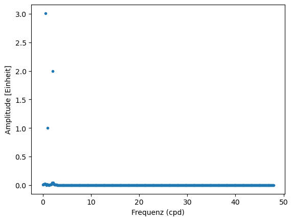

```python
# calculate the amplitude spektrum
amplitude = (2/N)*np.abs(data_fft)

plt.plot(freq, amplitude, '.')
plt.xlabel('Frequenz (cpd)')
plt.ylabel('Amplitude [Einheit]')
```

[output not shown]

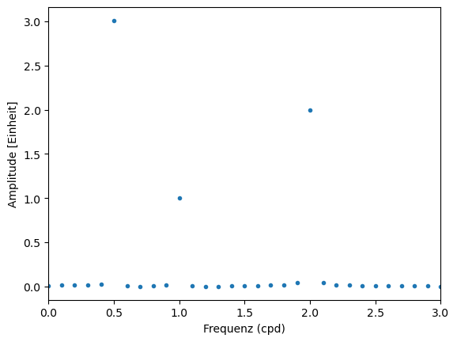

```python
# the amplitude scaled correctly
amplitude = (2/N)*np.abs(data_fft)

plt.plot(freq, amplitude, '.')
plt.xlabel('Frequenz (cpd)')
plt.ylabel('Amplitude [Einheit]')
plt.xlim(0,3)
```

### Frequenz- und Zeitdomäne

Man kann die DFT als ein mehrdimensionales Objekt verstehen:

- Eine Dimension beschreibt die **Zeitdomäne**
- Eine Dimension beschreibt die **Frequenzdomäne**

[figure not shown]

## Anwendung auf die Meeresspiegel Zeitreihe

### Das Amplitudenspektrum

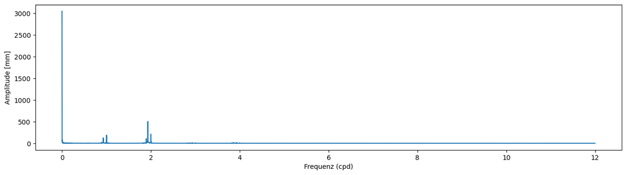

```python
N = len(sea_level)
T = 24

data_fft = np.fft.fft(sea_level['Sea level [mm]'])
data_fft = data_fft[0:int(N/2)]

freq = np.fft.fftfreq(N, d=1/T)
freq = freq[0:int(N/2)]

amplitude = (2/N)*np.abs(data_fft)

fig, ax = plt.subplots(figsize=(16,4))
ax.plot(freq, amplitude)
ax.set_xlabel('Frequenz (cpd)')
ax.set_ylabel('Amplitude [mm]')
plt.show()
```

**Hinweis**: Der Nullte Eintrag der FFT ist die durchschnittliche Abweichung von Null

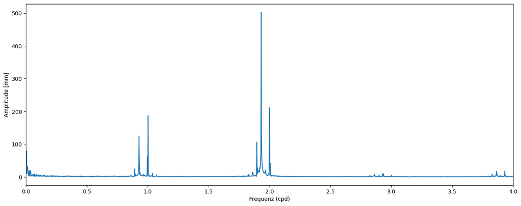

```python
fig, ax = plt.subplots(figsize=(16, 6))
ax.plot(freq[1:], amplitude[1:])
ax.set_xlabel('Frequenz (cpd)')
ax.set_ylabel('Amplitude [mm]')
ax.set_xlim(0, 4)
plt.show()
```

```python
result = pd.DataFrame({'Frequency': freq[1:], 'Amplitude': amplitude[1:]})
result.sort_values('Amplitude', ascending=False, inplace=True)
result
```

|  | Frequency | Amplitude |
| --- | --- | --- |
| 704 | 1.931727 | 503.494963 |
| 729 | 2.000228 | 211.264371 |
| 365 | 1.002854 | 187.401555 |
| 338 | 0.928873 | 124.666260 |
| 705 | 1.934467 | 119.012559 |
| ... | ... | ... |
| 4292 | 11.762987 | 0.006969 |
| 3714 | 10.179244 | 0.005686 |
| 3946 | 10.814933 | 0.005304 |
| 3883 | 10.642311 | 0.003813 |
| 4005 | 10.976596 | 0.001969 |

4378 rows × 2 columns

### Zusammenfassung

- Die "Peaks" im Amplitudenspektrum zeigen die Stärke (=Amplituden) der Frequenzkomponenten, welche in diesem Datensatz enthalten sind
- In diesem Beispiel sind die typischen Komponenten der Gezeiten zu sehen

*Hinweis*: Mehr Informationen zu Gezeitenkomponenten sind von der [NOAA Tides & Currents](https://tidesandcurrents.noaa.gov/harcon.html?unit=0&timezone=0&id=9410170&name=San+Diego%2C+San+Diego+Bay&state=CA) zusammengefasst.